# ChatGPT Workspace 使用说明

# ChatGPT Workspace 使用说明（图文版）

一个把**多个应用窗口**（ChatGPT、Claude、Cursor、VS Code、终端、浏览器……）收进同一个窗口、按格子排好的小工具。 给同时开着好几个聊天/编码窗口干活的人用：不用再来回切窗口找”那个在等我回话的”。

[figure not shown]

*↑ 实际界面（对话内容已打码）。左边工作区，右边 1×2 格子，每格一个真实的 ChatGPT 窗口。*

## 目录

1. 它是什么
   - 支持哪些应用（v47 新增）
2. 运行条件
3. 三步上手
4. 界面说明
5. 把 ChatGPT 放进格子的三种办法
6. 三种模式，选哪个
7. 常用操作速查
8. 常见问题
9. 配置文件与日志
10. 卸载

## 1. 它是什么

- 把**已经打开的**目标应用窗口（v47 起不再限于 ChatGPT），按「行 × 列」摆进一个工作区窗口的格子里
- 支持多个**工作区**（顶部标签页 / 左侧列表），一键切换；切走时那些窗口会自动让位
- 记住每个窗口放在哪一格，**下次启动自动认领**并摆好
- 关掉工作区时，所有窗口**放回你摆进去之前的位置和尺寸**

它不会替你打开 ChatGPT，也不改 ChatGPT 的任何设置 —— 它只是”指挥”已经开着的那些窗口站到指定位置。

### 支持哪些应用（v47 新增）

默认清单已经带了常用的一批：**ChatGPT 桌面版、Claude、Cursor、VS Code、PyCharm、Windows Terminal、PowerShell/cmd、 Chrome/Edge/Firefox、记事本、WPS、Obsidian、Typora** 等。

想加别的：在工具栏第二行的「目标进程」框里按逗号写进程名（如 `ChatGPT,Claude,Code,chrome`，带不带 `.exe` 都行）， 点「应用」立即生效；勾上「所有可见窗口」则接管一切有标题的窗口。

[figure not shown]

*↑ v47：槽位里装的可以是任意应用（图中是一个测试窗口）。底部下拉框按 `[进程名] 窗口标题` 显示； 配置对应 ini 里的 `targets=` 与 `allwindows=`*

**v48 起，专门照顾「全屏 / 无边框 / 置顶」这一类程序**（很多相机客户端、播放器就是这样）：

- **无标题栏、标题为空**的窗口：只要把进程名写进「目标进程」，它一样会出现在下拉框里（显示为 `(无标题)`）
- **默认全屏**的程序：接管时会被拉到槽位尺寸。实测一个 Qt 写的相机客户端（`zacam`，无边框、平时最小化/全屏）：从最小化状态拉起来摆进槽位后**稳定不动**，不会自己抢回全屏
- **置顶（Always on top）**的程序：接管期间自动摘掉置顶（否则它会一直压在工作区上面），退出时按原样还原
- **最小化 / 最大化状态精确还原**：原来最小化着的程序，关掉工作区后仍然是**最小化**（不会变成”屏幕外还显示着”）
- **死磕全屏的程序**（v49/v50）：自动按「悬浮 → 嵌入（子窗口）→ **镜像（DWM 缩略图）**」逐级升级。镜像模式下画面会缩放进槽位、**鼠标点击转发给原程序**，源窗口被压到最底层不挡人；整个过程约 10 秒，之后完全稳定

> 任务栏、开始菜单、输入法、桌面这些系统壳窗口**永远不会**被接管；程序自己也不会接管自己。

## 2. 运行条件

| 项目 | 要求 |
| --- | --- |
| 系统 | Windows 10 / 11（64 位） |
| 目标应用 | 先把要接管的程序打开。默认清单含 ChatGPT 桌面版、Claude、Cursor、VS Code、终端、浏览器、记事本等，也可自己加进程名 |
| 运行环境 | 什么都不用装。双击 `ChatGPTWorkspace.exe` 就能跑（用系统自带的 .NET Framework） |
| 权限 | 普通用户即可，**不需要管理员** |
| 杀软提示 | 若被 SmartScreen 拦，点「更多信息 → 仍要运行」即可 |

## 3. 三步上手

1. **打开 ChatGPT 桌面版**，要几个窗口就开几个（每个窗口是个独立会话）。
2. **双击 `ChatGPTWorkspace.exe`**。
3. 需要几个格子就设「行 / 列」；程序会**自动**把发现的 ChatGPT 窗口依次填进空槽位。

> 想调整：在槽位下面的下拉框里换窗口，或者直接拖动窗口（见下一节）。满意后点「保存布局」。

## 4. 界面说明

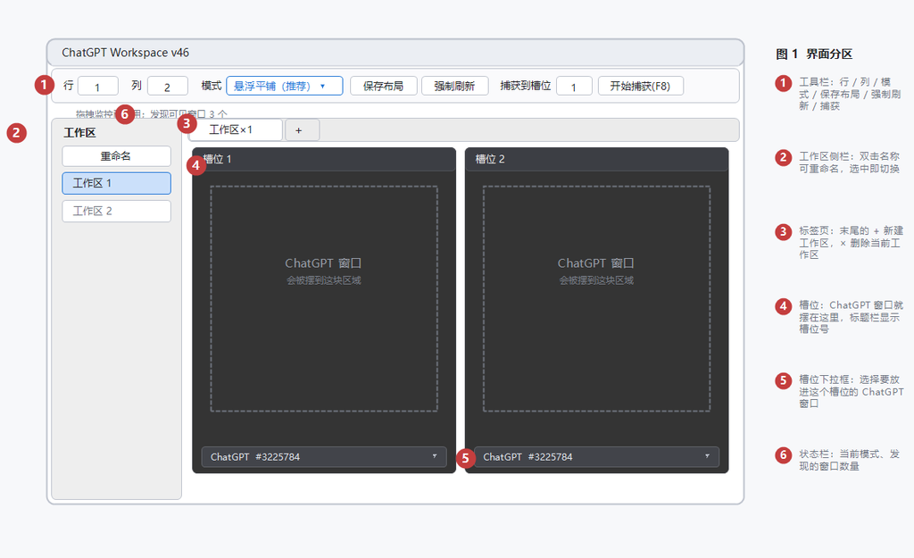

界面分区

| 编号 | 位置 | 说明 |
| --- | --- | --- |
| ① | 工具栏 | 第一行：`行`/`列`、`模式`、`保存布局`、`强制刷新`、`捕获到槽位` + `开始捕获(F8)`；第二行（v47）：`目标进程` 输入框、`所有可见窗口` 开关、`应用` 按钮 |
| ② | 左侧「工作区」 | 双击名称可**重命名**，点一下即切换；`重命名` 按钮同效 |
| ③ | 标签页 | `工作区×1` 是当前工作区，右边 `×` 删除它；末尾 `+` 新建工作区 |
| ④ | 槽位 | ChatGPT 窗口就停在这块区域，左上角显示槽位号 |
| ⑤ | 槽位下拉框 | 选择放进这个槽位的 ChatGPT 窗口（列出的就是当前发现的窗口） |
| ⑥ | 状态栏 | 当前模式、发现的窗口数量等提示 |

## 5. 把 ChatGPT 放进格子的三种办法

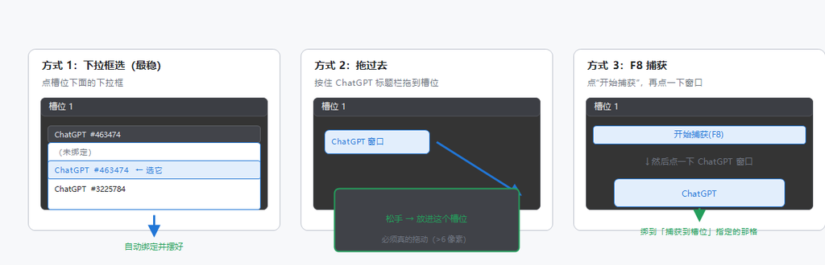

三种绑定方式

0. **拖进来 / 捕获就会自动认（v51）**：就算某个程序不在「目标进程」清单里，你也可以直接把它拖到槽位上， 或点「开始捕获(F8)」再点一下它 —— 程序会自动把它的进程名加进「目标进程」并完成绑定。
1. **下拉框选（最稳）**：点槽位下面的下拉框 → 选中要放的窗口，立刻放进该槽位（下拉框里只会列出”目标进程”清单里的窗口）。
2. **拖过去**：按住 ChatGPT 窗口的**标题栏**拖动，鼠标移到目标槽位上松手。 （必须真的拖动超过 6 像素，随手点两下不会被误判成拖拽。）
3. **F8 捕获**：先在工具栏「捕获到槽位」里填目标槽位号 → 点「开始捕获」→ 切到 ChatGPT 窗口点一下。 如果 F8 被别的软件占用，程序会自动改用 **Ctrl+Alt+F8**（状态栏会提示）。

小规则： - 一个窗口同时只能占一个格子；把它绑到新格子，旧格子会自动腾空。 - 想让某格空出来：下拉框选「（未绑定）」。 - 窗口标题会随会话变化（`ChatGPT` → 会话名），**不影响绑定**。

## 6. 三种模式，选哪个

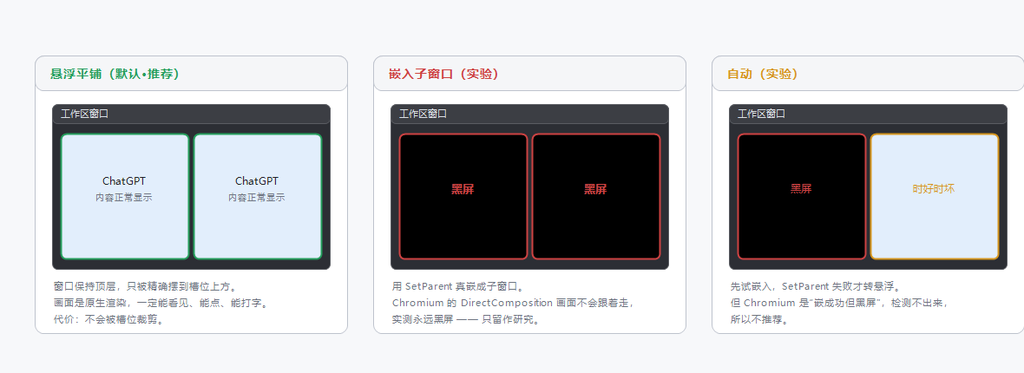

三种模式

| 模式 | 效果 | 建议 |
| --- | --- | --- |
| **悬浮平铺**（默认） | 窗口保持独立，被**精确摆到**格子上方，内容原生渲染 | ✅ 就用这个 |
| 嵌入子窗口（实验） | 把窗口”塞”进格子里当子窗口 | ❌ 会**黑屏**（见下） |
| 自动（实验） | 先试嵌入，失败才转悬浮 | ❌ 不推荐 |

> **为什么”嵌入”会黑屏？** ChatGPT 桌面版是 Electron/Chromium，画面走 DirectComposition 提交到它自己的窗口上； 一旦被塞进别人的窗口里，合成目标就对不上，于是窗口”在里面”了但永远不画东西。这是系统层面的限制，不是设置问题。 所以默认走「悬浮平铺」—— 画面一定正常，只是窗口不会被格子裁切。

## 7. 常用操作速查

| 想做什么 | 怎么做 |
| --- | --- |
| 改格子数量 | 工具栏 `行` / `列`，改完自动重排 |
| 记住当前布局 | 点 `保存布局`（写入 `chatgpt-workspace.ini`） |
| 一次性重排 + 重画 | 点 `强制刷新` |
| 换某格的窗口 | 槽位下拉框，或把另一个窗口拖过去 |
| 让某格空着 | 下拉框选「（未绑定）」 |
| 新建 / 删除工作区 | 顶部标签栏的 `+` / 标签上的 `×` |
| 重命名工作区 | 双击左侧列表里的名字（或选中后按 `F2`） |
| 切换工作区 | 点标签，或点左侧列表 |
| 捕获窗口快捷键 | `F8`（被占用时 `Ctrl+Alt+F8`） |
| 关闭工具 | 点窗口 `×` 或 `Alt+F4`（**不要**用任务管理器强杀，见 FAQ） |

## 8. 常见问题

**Q1：格子是空的 / 灰的，明明已经绑定了？** - 先看槽位下拉框是否显示着某个窗口；如果显示「（未绑定）」，重新选一次。 - 如果绑的窗口被你**最小化**了，程序会自动把它还原并摆好（1 秒内）。 - 还不行就点一次「强制刷新」。

**Q2：弹出的提示框 / 下拉列表被 ChatGPT 窗口挡住了，点不到？** - v46 起已修：弹出自己的对话框和下拉框时，会把 ChatGPT 窗口临时沉到最底层，关闭后自动恢复。 - 如果你用的是更早的版本，请升级到 v46+。

**Q3：切到浏览器/别的程序，ChatGPT 窗口还压在它们上面？** - 不会。切走时它们会被沉到最底层（被别的程序自然盖住）；**最小化**工作区窗口时则直接隐藏。

**Q4：我用任务管理器强杀了它，ChatGPT 窗口变得没边框/怪怪的？** - 强杀不会执行”归还窗口”的收尾动作。**重启一下 ChatGPT 应用即可恢复**。 - 正确做法：用窗口的 `×` 或 `Alt+F4` 关闭工具。

**Q5：关掉工作区后，我的窗口会乱吗？** - 不会。每个窗口会回到**被摆进格子之前的位置和尺寸**（原本最小化/最大化的状态也会还原）。

**Q6：ChatGPT 换了会话、窗口标题变了，绑定会丢吗？** - 不会。程序记的是”进程 + 序号”而不是标题。

**Q7：多显示器 / 显示缩放能用吗？** - 能。窗口会被搬到工作区所在的那块屏幕的格子位置。

**Q8：能管 Claude、Cursor、浏览器之类的窗口吗？** - v47 起可以。在工具栏第二行「目标进程」里加上它们的进程名（逗号分隔，如 `ChatGPT,Claude,Cursor,Code,chrome`），点「应用」； 勾「所有可见窗口」则接管全部。任务栏/开始菜单/输入法等系统窗口永远会跳过。

**Q9：格子里的窗口能打字吗？** - 能。是同一个真实窗口，输入法、复制粘贴都和你平时一样。

**Q11：有个程序死活要全屏（比如某些相机客户端），就是接管不了怎么办？** - 不用你操心，工具会自己逐级升级：**悬浮** → 每次都弹回满屏就改**嵌入子窗口** → 连子窗口也不接受就改**镜像（DWM 缩略图）**。 实测一个强制全屏 + GPU 渲染的相机客户端（`zacam`）：约 10 秒走完三级，之后完全稳定， 槽位里能看到它的实时画面，点槽位等于点它（详见 Q12）。 - 如果连镜像都失败（系统合成被禁用等极少数情况），工具会放开该窗口并说明原因，不会留下空槽位或一直闪。 - 想让它彻底正常，最省事的办法还是**在它内部切到窗口模式**（多数相机客户端：双击画面 / `Esc` / `F11`）。

**Q12：镜像模式是什么？有什么限制？** - **做法**：完全不 reparent、不改它的尺寸 —— 让这个程序保持它自己的样子（程序把它压到工作区窗口下面，看不见但不影响它渲染）， 然后用 Windows 的 DWM 缩略图把它的**实时画面**缩放显示进槽位。按比例显示，上下/左右会留黑边。 - **点击转发**：在镜像画面上点击/右键/滚轮，会按比例换算成源窗口的客户区坐标后转发过去，等于你点在原窗口上（已实测坐标正确）。 - **键盘**：也会尽力转发（普通字母数字、回车、方向键等）；但**中文输入法、长文本编辑**这类需要真实焦点的操作转发不了 —— 需要输入文字时，建议在该程序里切窗口模式，或把它临时切前台操作。 - **镜像是不是实时的**：是。实测用”每 150ms 变色”的动态源验证，镜像区域 0.7 秒内有 **82%** 的像素在变化。 注意：如果镜像看起来”不动”，先确认**源程序自己那画面本来就在动**（例如相机客户端没在播放预览时，镜像自然也静止）。 - **源窗口去哪了**（v51）：为了让它持续渲染，程序会把它挪到**另一块屏幕**（保持它自己的尺寸）； 只有一块屏幕时会把它压到最底层，此时部分程序会停止渲染导致镜像变静帧，状态栏会提示你。 - **限制**：镜像依赖系统桌面合成（Windows 8 以后默认开启）；如果程序用了 DRM/受保护内容，镜像可能是黑的。 - 什么时候用：某个程序**强制全屏**或**画面是 GPU 合成**（嵌入后黑屏），悬浮又被它抢回满屏时，用「镜像」模式最合适。 - 想手动指定：工具栏「模式」里直接选「镜像（DWM 缩略图·可点击）」，或 ini 里写 `mode=mirror`。

**Q10：像相机客户端那种”一打开就全屏、还没标题栏”的程序怎么办？** - 把它的进程名加进工具栏第二行的「目标进程」（例如 `zacam`），点「应用」；然后在槽位下拉框里选它 （显示成 `[zacam] zacam #句柄`），或点「开始捕获(F8)」再点一下那个画面。 - 全屏 / 无边框 / 置顶都已经处理：接管时会被摆进槽位、置顶会被临时摘掉；关掉工作区后回到原本的位置和最小化/最大化状态。 - 万一某个程序死活要抢全屏（状态栏会提示），先在那个程序里切到窗口模式（多数相机客户端是双击画面 / `Esc` / `F11`）再绑定。

## 9. 配置文件与日志

都在**程序所在的文件夹**（和 exe 同级）：

| 文件 | 说明 |
| --- | --- |
| `chatgpt-workspace.ini` | 布局配置，点「保存布局」时写入 |
| `ChatGPTWorkspace.log` | 运行日志，出问题先看它 |

`chatgpt-workspace.ini` 示例：

```
rows=1
columns=2
mode=float      ; float=悬浮平铺(推荐) / embed=嵌入(实验) / auto=自动(实验)
slot1=ChatGPT   ; 也可以直接写序号，如 slot1=1
slot2=
targets=ChatGPT,Claude,Cursor,Code,WindowsTerminal   ; v47：要接管的进程名（逗号分隔）
allwindows=0    ; v47：1=接管所有有标题的可见窗口（系统壳窗口仍跳过）
```

- 删掉 ini 不会坏，只是回到默认（1 行 2 列、悬浮平铺、启动自动认领窗口）。
- **换电脑/挪目录时把 ini 和 exe 一起带走**，配置才会跟着走。

## 10. 卸载

1. 用窗口 `×` 正常关闭（让它把 ChatGPT 窗口放回原位）。
2. 删掉整个程序文件夹即可。

它不写注册表、不装服务、不开机自启，删目录就干净了。

### 附：版本

当前版本 **v51**。v50 起支持**镜像模式**（DWM 缩略图 + 点击转发），v51 修正了镜像的实时性并让绑定更省事：

- **v47：支持其它应用** —— 目标进程列表可配置 / 「所有可见窗口」开关；下拉框按 `[进程名] 标题` 显示
- **v48：全屏 / 无边框 / 置顶 / 最小化** —— 无标题窗口也能认（写明进程名即可）；接管期间摘掉置顶、退出还原； 最小化/最大化状态精确还原
- **v49：不闪、不硬碰** —— 悬浮窗口只在”真的被宿主压住”时才提一次 z 序（v47/v48 是每秒无条件置顶， 视频类窗口会因此一直闪）；置顶只摘一次；检测到”全屏无边框”先请它退出全屏
- **v50：镜像模式（DWM 缩略图）+ 点击转发** —— 不 reparent、不改尺寸，把源窗口的实时画面缩放进槽位； 鼠标点击/右键/滚轮按比例映射后转发给源窗口；键盘尽力转发。死磕全屏的程序自动升级到这一级
- **v51：镜像实时性 + 免手填进程名** —— 源窗口改挪到另一块屏幕（压到最底层会让部分程序停止渲染、镜像变静帧； 实测动态源镜像 0.7 秒有 82% 像素在变）；拖拽/捕获不在清单里的程序时会自动把它的进程加进「目标进程」
- 悬浮模式下窗口能正常显示（嵌入模式黑屏问题 → 默认改为悬浮平铺）
- 输入丢焦点、面板闪黑、嵌入时好时坏
- 误触拖拽把窗口搬走
- **弹出对话框 / 下拉列表被 ChatGPT 窗口挡住、点不到按钮**
- 启动自动认领窗口、窗口标题变化不再丢绑定、最小化窗口会自动还原

### 附：本说明书的图

- `docs/images/01~03` 是程序绘制的示意图，生成脚本：`docs/_make_guide_images.ps1`
- `docs/images/04` 是真实截图，抓图工具：`docs/_capture.exe`（源码 `docs/_capture.cs`）